# S2.5: il simulatore completo produce conteggi come quelli dei sei tessuti veri?

geo_spatialtrans, report di step (protocollo v2)

Published

November 9, 2026

# In breve

### In breve: il simulatore completo produce conteggi come quelli dei sei tessuti veri?

**A cosa serviva.** Questo step mette insieme tutti i passi del simulatore di Visium HD in una sola funzione: dalle cellule ai conteggi nei quadratini da 2 e da 8 µm, con la verità di riferimento per mettere alla prova i metodi. Poi confronta le 30 aree simulate con le stesse 30 aree vere su sette misure: trascritti per quadratino, quadratini vuoti, geni rilevati (a 2 e a 8 µm), contrasto fra nucleo e citoplasma attorno. Come soglia usa i margini corretti che hai adottato dopo lo step sulle aree sovrapposte, e confronta sugli stessi quadratini dei due lati, come avevi scelto.

**Cosa abbiamo trovato.**

1. **Dopo una sola ritaratura della profondità, trascritti e geni per quadratino tornano sul vero in tutti e sei i tessuti, a 2 e a 8 µm.**
   - Prima della ritaratura l’intestino aveva 14 trascritti su 100 in meno del vero e il cervello 12 in meno. La causa era nota: il fattore di profondità era stato tarato senza i trascritti che lo spostamento porta sul vetro, e la verifica era rinviata a qui.
   - Il fattore nuovo cambia poco nello stroma (1 % in meno) e di più nell’intestino (17 % in più). Che i trascritti tornino giusti è in gran parte per costruzione, perché il fattore si ritara sulle stesse aree; i geni rilevati e i blocchi da 8 µm invece non sono tarati, e tornano anche loro.
   - Il confronto ha potere: senza fattore di profondità il simulato risulta fuori dal vero nel linfonodo, nel cervello e nel cuore.
2. **Restano tre scarti, tutti già visti prima o attesi.**
   - Nell’intestino e nel tumore del colon il simulato ha da un diciassettesimo a un tredicesimo dei quadratini vuoti veri (già visto quando abbiamo aggiunto le strisce).
   - Nel tumore del colon il contrasto fra nucleo e citoplasma è più alto del vero: 0,90 contro 0,82-0,88. Con il margine del ±10 % che usavamo prima sarebbe giusto.
   - Nel cuore i conteggi veri hanno una direzione, quella delle fibre (indice 0,25), mentre il simulato non ne ha (0,05) perché le cellule sono rotonde. Era il controllo negativo previsto: la misura vede il limite.
3. **Il simulatore completo sta nei 5 minuti e negli 8 GB per un’area di 1 mm², anche nel tumore del colon, il tessuto più carico.**
   - A macchina libera il tumore impiega da 2 minuti e mezzo a 4 minuti, con un picco da 6 a 7,2 GB. Con i blocchi di cellule di prima un’area del tumore arrivava a 8,9 GB: li ho dimezzati, senza perdere tempo.
   - Sotto 7 GB non si scende per un’area così carica: un’area di cattura intera andrà fatta a pezzi.
4. **Il confronto dipende molto da quali quadratini si chiamano tessuto.** Sugli stessi quadratini dei due lati, come hai scelto, l’intestino torna sul vero. Con i quadratini di Space Ranger, che contano più bordo con pochi trascritti, lo stesso simulato risulterebbe sopra il vero nei geni rilevati.
5. **Tre revisori indipendenti hanno ricalcolato tutto con codice proprio e trovato due difetti, corretti, che non cambiano nessun numero.** Riguardavano lo stato del generatore casuale dell’utente e un controllo degli argomenti. Due esiti del cervello prima della ritaratura stanno così vicini al margine che li decide il caso del ricampionamento; dopo la ritaratura sono confermati.

**Cosa devi decidere.**

1. **Teniamo come limiti dichiarati i pochi quadratini vuoti nell’intestino e nel tumore e il contrasto troppo alto nel tumore, da riprendere quando rivedremo la densità delle cellule nei preset? Consiglio di sì.**
   - Le due cose toccano gli stessi tessuti densi, e le cause possibili (buchi piccoli nel tessuto, densità delle cellule, nuclei simulati con meno trascritti del vero) sono tutte nella densità dei preset, che dovevamo già rivedere.
   - Alternativa: uno step subito su questi due scarti. Conseguenza: lavoro sul livello delle cellule prima di chiudere lo Step 2, senza un’ipotesi già pronta da provare.
2. **Teniamo come limite dichiarato che il cuore simulato non ha la direzione delle fibre? Consiglio di sì.**
   - Era già un limite scritto del livello delle cellule; ora sappiamo che si vede nei conteggi, con una misura che lo coglie.
   - Alternativa: cellule allungate e orientate nel cuore. Conseguenza: cambia il modo in cui il livello delle cellule disegna i territori, uno step grande.

**Comunque**: lo Step 2 ha la sua funzione completa e il fattore di profondità nuovo nei preset; la verifica su una sezione intera e un’area di cattura intera a pezzi andranno nello step sulle prestazioni; la correzione dei generatori casuali dei passi precedenti e la variabilità fuori dal nucleo restano negli step già previsti.

Appena decidi questi 2 punti, lo step è chiuso.

**Sui tempi di calcolo.** Misurati da me sul server, con al massimo 6 processi: il pannello principale (60 simulazioni) circa 18 minuti, la controprova (30) circa 10, il pannello dopo la ritaratura (60) circa 26 minuti, con il server carico per i revisori. Per un’area del tumore del colon da sola, a macchina libera, da 149 a 232 secondi.

# Dubbi rinviati

| cosa | perché | cosa serve per chiuderlo | step destinatario | voce di BACKLOG |
| --- | --- | --- | --- | --- |
| quadratini vuoti in tessuto: simulato da un diciassettesimo a un tredicesimo del vero in intestino e tumore (dopo R-2) | non vengono dalle strisce (S2.4) né dalla profondità | origine (buchi piccoli nel tessuto, densità dei preset, cattura locale) | revisione della densità dei preset (con BL-167, BL-213, BL-218, BL-222) | BL-226 (aggiornata) |
| rapporto nucleo/corona del tumore del colon sopra il vero (0.90 contro 0.82-0.88) sulla geometria dello Step 1 | sulla geometria vera era giusto (S2.0, S2.3); la differenza viene dal livello cellulare | confronto sulla geometria vera e simulata con lo stesso r, con la densità dei preset rivista | revisione della densità dei preset | BL-234 |
| cuore: i conteggi veri hanno l’orientamento delle fibre (indice 0.25), il simulato no (0.05) | cellule isotrope (limite dello Step 1) | cellule allungate e orientate nel livello cellulare, se si sceglie | nessuno (limite dichiarato, DEC-070) | BL-235 (chiusa) |
| indice di orientamento: soglia del rumore (circa 0.5 per campi non correlati); simulato più orientato del vero in intestino, tumore, linfonodo (contrasto dei bordi delle regioni e dei lumi, strisce ne… | la misura dipende dalla correlazione del campo | misura con un nullo per area (permutazione) e lumi con materiale (BL-201) | da assegnare | BL-236 |
| `frame_open` usa il riquadro delle regioni, non la finestra dell’area (A1_r1: tessuto da 5.48 µm, bordo trattato come aperto) | scelta di S2.3 | riquadro della finestra come argomento, effetto misurato | da assegnare | BL-237 |
| stato del generatore con Box-Muller e `sample.kind = "Rounding"` non ripristinato del tutto | comune a tutte le funzioni dei passi | ripristino della memoria di Box-Muller o avviso documentato | con BL-224 | BL-238 |
| esiti a ridosso del margine decisi dal seme del bootstrap (B = 2000, 5 aree) | deviazione standard Monte Carlo degli estremi fino al 9 % | B più grande o probabilità Monte Carlo per gli esiti a ridosso | da assegnare (metodo dei confronti) | BL-239 |
| verifica della profondità su una sezione intera; area di cattura intera a tessere (picco di circa 7 GB per 70 milioni di trascritti) | perimetro (scelta di Luca) | step di prestazioni con l’ottimizzazione del livello cellulare (BL-144) | step di prestazioni | BL-205, BL-214 (aggiornate) |
| banco della taratura del campo | perimetro | con la variabilità fuori dal nucleo | con BL-220 | BL-223 |

# Cancelli, regole e previsioni

Pre-registrazione: cancelli e funzione `3badae6`; ok di Luca sulle previsioni, sulle soglie, sulla regola R-2 e sulle controprove il 2026-11-09 («Ok, come proposte (Recommended)»), commit `e155d62`; calcolo, revisione e correzioni `5eed7c8`. File dello step: `docs/steps/S2.5.md`.

Tabelle: `results/S2.5/S2.5_verdicts_<variante>.csv` (una riga per giudizio; varianti main, main_r2, depth_off), `S2.5_verdict_counts_<variante>.csv`, `S2.5_sensitivity_<variante>.csv`, `S2.5_measures_<variante>.csv`, `S2.5_R2_depth.csv`, `S2.5_real_refs.csv`, `S2.5_real_areas.csv`, `S2.5_sim_<variante>.csv`, `S2.5_G2.csv`, `S2.5_G2_truth8.csv`.

### Regole

- **R-1, blocchi**: 4 × 10⁶ trascritti per blocco; cellule per blocco da 93 (cervello) a 2 000 (linfonodo, tetto) nel pannello main; P-8 sotto. Dopo PH-1 il valore predefinito della funzione diventa 2 × 10⁶ (correzione C-6; il pannello resta quello con 4 × 10⁶).
- **R-2, fattore di profondità sulla catena completa** (`S2.5_R2_depth.csv`): f di S2.2 → f’: intestino 0.867 → 1.013, tumore 0.893 → 0.954, stroma 1.584 → 1.561, linfonodo 0.787 → 0.819, cervello 1.252 → 1.428, cuore 2.625 → 2.939 (rapporto (U_vero − b)/(U_sim − b) da 0.986 a 1.168). I fattori ritarati diventano quelli del preset (`visium_hd_depth_factor()`, decisione tecnica DEC-067).

### Cancelli

| id | esito | dettaglio |
| --- | --- | --- |
| G-1 | superato | batteria 40/40 (`S2.5_G1_tests.txt`; 35 asserzioni pre-registrate più 5 aggiunte dopo la revisione: e6, f5b, f6b, d5, d6); mutanti 16/16 rilevati (`S2.5_mutants.txt`; prima esecuzione 11/12, un framme… |
| G-2 | superato | 150 esecuzioni (main 60, depth_off 30, main_r2 60): conservazione 150/150, nessun NA, catturati |
| G-3 | superato | lato vero, pannello main k = 0 e misure rifatti in un’altra cartella con 2 e 3 processi invece di 3 e 6, con il codice dopo le correzioni: 241 file identici (`S2.5_G3.txt`) |
| G-4 | superato | (a) 230 file letti, md5 identici prima e dopo (`S2.5_md5_diff.txt` vuoto); (b) batterie S2.1 21/21, S2.2 36/36, S2.3 39/39, S2.4 37/37; (c) A2_r1 e A6_r1 con i semi e i blocchi di S2.4: totali per qua… |
| G-5 | superato, con rilievi | tre revisori («Revisione avversariale»): ricalcoli entro la tolleranza; due difetti del codice (generatore dell’utente senza seme, strati senza nome) corretti senza effetto sui risultati; tre controll… |

### Previsioni

Conteggi per esito (confermata / indeterminata / smentita):

| previsione | pannello main | dopo R-2 (main_r2) |
| --- | --- | --- |
| P-1 UMI per quadratino di 2 µm | 4 / 1 / 1 | 6 / 0 / 0 |
| P-2 quadratini di 2 µm vuoti | 4 / 0 / 2 | 4 / 0 / 2 |
| P-3 geni per quadratino di 2 µm | 4 / 1 / 1 | 6 / 0 / 0 |
| P-4 UMI per blocco di 8 µm | 4 / 1 / 1 | 6 / 0 / 0 |
| P-5 blocchi di 8 µm vuoti | 6 / 0 / 0 | 6 / 0 / 0 |
| P-6 geni per blocco di 8 µm | 5 / 1 / 0 | 6 / 0 / 0 |
| P-7 rapporto nucleo/corona | 3 / 2 / 1 | 3 / 2 / 1 |
| P-8 tempo e memoria (12 giudizi) | 12 / 0 / 0 | 11 / 1 / 0 |
| P-9 orientamento | 2 / 3 / 1 | 2 / 3 / 1 |

- **P-1, P-3, P-4, P-6 (pannello main)**: intestino smentita come atteso (UMI a 2 µm 25.06 [24.72, 25.49] contro 26.21-32.34; geni a 2 µm 24.04 contro 24.46-29.83; UMI a 8 µm 398.9 contro 419.0-514.4; geni a 8 µm confermata, 328.3 contro 323.8-385.3); cervello indeterminata (attesa smentita): UMI a 2 µm 39.07 [37.77, 40.56] contro 40.43-47.77. Dopo R-2 tutte confermate in 6 su 6 (UMI a 2 µm simulato / vero 0.9999-1.0001: per costruzione, il fattore si ritara sulle stesse aree e si verifica con gli stessi semi; non per costruzione i geni e i blocchi di 8 µm: geni a 8 µm simulato / vero 1.005-1.064).
- **P-2**: smentita per difetto nell’intestino (dopo R-2 0.00040 contro 0.0047-0.0093, un diciassettesimo) e nel tumore (0.00042 contro 0.0041-0.0071, un tredicesimo), come attesa; confermata negli altri quattro (stroma 0.42 del vero, intervallo largo).
- **P-5**: confermata 6/6 (simulato 0 blocchi vuoti in tutte le esecuzioni).
- **P-7**: smentita per eccesso nel tumore del colon (dopo R-2 0.901 [0.888, 0.917] contro 0.818-0.883), come attesa; indeterminata nell’intestino (0.955 contro 0.922-0.951) e nel cervello (1.363 contro 1.357-1.411); confermata in stroma, linfonodo, cuore. Con la banda di ±10 % di S2.3 (sensibilità) confermata in 6 su 6.
- **P-8** (giudicata come pre-registrata: media delle 5 aree ± 2 errori standard per tessuto contro 0-300 s e 0-8 GB): pannello main 12/12 confermate (singole esecuzioni 19-237 s; memoria media del tumore 7.09 GB, ± 2 SE fino a 7.71 GB); main_r2 tempo del tumore indeterminato (276.8 [238.9, 314.8] s, server carico per la revisione e i mutanti). La regola non giudica le singole esecuzioni: oltre 8 GB ce ne sono 3 su 150, tutte nell’area A2_r4 (8 318 MB main, 8 749 MB main_r2, 9 858 MB depth_off). Rimisurato a macchina libera con i predefiniti finali (PH-2): 149-232 s e 6.0-7.2 GB nelle 5 aree del tumore.
- **P-9**: cuore smentita per difetto (dopo R-2 0.048 [0.035, 0.059] contro 0.086-0.41), come attesa (CP-2); indeterminata in intestino (0.203 contro 0.105-0.241), tumore (0.159 contro 0-0.177) e linfonodo (0.216 contro 0-0.184), dove il simulato supera o tocca il vero (vedi «Revisione avversariale» e BL-236); confermata in stroma e cervello. Con `kappa_boot_box` (sensibilità, C-3) nessun esito cambia.
- **Sensibilità con la tabella adottata di R7** (definizione sr, `S2.5_sensitivity_main_r2.csv`): dopo R-2 l’intestino supera i valori di Space Ranger (UMI a 2 e 8 µm indeterminate, geni a 2 e 8 µm smentiti per eccesso; rapporto nucleo/corona smentito per difetto, 0.943-0.965 contro 0.965-1.006), perché R-2 ritara sui quadratini delle regioni, che hanno più trascritti di quelli di Space Ranger (29.27 contro 27.14). Cambiano anche: vuoti a 2 µm del tumore confermati (l’intervallo di Space Ranger arriva a 0), geni a 2 e 8 µm del cervello indeterminati. Gli altri esiti come con la definizione reg. Mostra di quanto la definizione del tessuto pesa nel confronto (DEC-064).

### Controprove

- **CP-1** (`S2.5_verdicts_depth_off.csv`): con il fattore di profondità 1 l’UMI per quadratino di 2 µm è smentito nel linfonodo (14.08 contro 8.76-13.56), nel cervello (31.23 contro 40.43-47.77) e nel cuore (1.21 contro 2.06-5.05): superata, il confronto ha potere in quei tre tessuti. Intestino, tumore e stroma confermati, come atteso (nell’intestino senza fattore 28.80, più vicino al vero che con il fattore di S2.2).
- **CP-2**: P-9 smentita per difetto nel cuore nel pannello main e in main_r2: superata, la misura vede il limite noto delle cellule isotrope.

### Misure

- Fattore di sovra-generazione M per esecuzione: 2.93 (cuore) … 5.94 (tumore); media per tessuto 3.20 (cuore) … 5.00 (stroma). Valore atteso dei catturati / bersaglio di R4 0.997-1.004 per esecuzione (pannello main); catturati entro |z| ≤ 2.19 dall’atteso.
- BL-212: quadratini in tessuto senza territorio 155 su 6 616 090 (2.3e-5): 141 nell’area A5_r1 del cervello, 14 in tre aree del cuore, 0 altrove.
- BL-219: quota degli UMI veri dello stroma sui 522 geni con profilo nullo 0.99 % [0.45 %, 1.67 %] (E-3; limite dichiarato, DEC-065).

## Tutti i giudizi

Per ogni tessuto: valore vero sugli stessi quadratini dei due lati (definizione reg, DEC-064) con l’intervallo corretto di R7; simulato con l’intervallo bootstrap delle 10 esecuzioni (5 aree × 2 semi) per il fattore delle poche aree (1.632). Tabelle: `results/S2.5/S2.5_verdicts_main.csv`, `S2.5_verdicts_main_r2.csv`. P-8 (tempo e memoria) è nella sezione «Previsioni» qui sopra.

| id | tessuto | misura | vero (stima) | intervallo del vero (R7) | simulato, fattore di S2.2 | esito | simulato, fattore di R-2 | esito |
| --- | --- | --- | --- | --- | --- | --- | --- | --- |
| P-1 | intestino | mean_umi2 | 29.27 | [26.21, 32.34] | 25.06 [24.72, 25.49] | smentita | 29.27 [28.87, 29.72] | confermata |
| P-2 | intestino | frac_empty2 | 0.006699 | [0.00472, 0.009333] | 0.0008099 [0.0006022, 0.001018] | smentita | 0.0003964 [0.0003057, 0.0004724] | smentita |
| P-3 | intestino | mean_genes2 | 27.15 | [24.46, 29.83] | 24.04 [23.72, 24.39] | smentita | 27.95 [27.58, 28.41] | confermata |
| P-4 | intestino | mean_umi8 | 466 | [419, 514.4] | 398.9 [393.3, 405.2] | smentita | 465.9 [459.3, 474.1] | confermata |
| P-5 | intestino | frac_empty8 | 0 | [0, 9.505e-05] | 0 [0, 0] | confermata | 0 [0, 0] | confermata |
| P-6 | intestino | mean_genes8 | 354.3 | [323.8, 385.3] | 328.3 [324.1, 332.7] | confermata | 377 [372.1, 382.5] | confermata |
| P-7 | intestino | star | 0.9371 | [0.922, 0.9508] | 0.9545 [0.9433, 0.9656] | indeterminata | 0.9548 [0.943, 0.9649] | indeterminata |
| P-9 | intestino | aniso8 | 0.1735 | [0.1046, 0.2406] | 0.207 [0.1397, 0.2911] | indeterminata | 0.2035 [0.1301, 0.2768] | indeterminata |
| P-8 | intestino | elapsed_sim_s |  | [0, 300] | 99.45 [87.83, 111.1] | confermata | 152.2 [134.3, 170.1] | confermata |
| P-8 | intestino | peak_mb |  | [0, 8192] | 5038 [4717, 5359] | confermata | 5242 [4924, 5560] | confermata |
| P-1 | tumore del colon | mean_umi2 | 47.93 | [36.61, 59.26] | 44.9 [44.26, 45.61] | confermata | 47.93 [47.2, 48.68] | confermata |
| P-2 | tumore del colon | frac_empty2 | 0.005588 | [0.004055, 0.007102] | 0.0004861 [0.000415, 0.0005583] | smentita | 0.0004231 [0.0003663, 0.0004786] | smentita |
| P-3 | tumore del colon | mean_genes2 | 45.66 | [35, 56.33] | 42.92 [42.36, 43.56] | confermata | 45.73 [45.07, 46.4] | confermata |
| P-4 | tumore del colon | mean_umi8 | 764.2 | [560.6, 981] | 716.5 [703.5, 729.5] | confermata | 764.9 [751.1, 777.7] | confermata |
| P-5 | tumore del colon | frac_empty8 | 0 | [0, 8.273e-05] | 0 [0, 0] | confermata | 0 [0, 0] | confermata |
| P-6 | tumore del colon | mean_genes8 | 617.1 | [472.5, 751.4] | 588.9 [579.4, 598.5] | confermata | 624.3 [614.3, 633.6] | confermata |
| P-7 | tumore del colon | star | 0.8505 | [0.8182, 0.8829] | 0.9027 [0.8908, 0.9189] | smentita | 0.9015 [0.8882, 0.9174] | smentita |
| P-9 | tumore del colon | aniso8 | 0.08685 | [0, 0.1771] | 0.1623 [0.1071, 0.2036] | indeterminata | 0.1588 [0.1113, 0.1997] | indeterminata |
| P-8 | tumore del colon | elapsed_sim_s |  | [0, 300] | 183.3 [154.9, 211.6] | confermata | 276.8 [238.9, 314.8] | indeterminata |
| P-8 | tumore del colon | peak_mb |  | [0, 8192] | 7093 [6478, 7707] | confermata | 7531 [6923, 8140] | confermata |
| P-1 | stroma | mean_umi2 | 19.24 | [8.643, 26.72] | 19.51 [19.38, 19.67] | confermata | 19.24 [19.11, 19.39] | confermata |
| P-2 | stroma | frac_empty2 | 0.02219 | [0.002124, 0.04402] | 0.008774 [0.008534, 0.008934] | confermata | 0.009315 [0.009125, 0.009499] | confermata |
| P-3 | stroma | mean_genes2 | 18.28 | [8.469, 25.47] | 18.6 [18.48, 18.71] | confermata | 18.34 [18.23, 18.47] | confermata |
| P-4 | stroma | mean_umi8 | 308 | [142, 427.7] | 312.1 [310.1, 314.5] | confermata | 307.7 [305.7, 310.1] | confermata |
| P-5 | stroma | frac_empty8 | 0.0006366 | [0, 0.007745] | 0 [0, 0] | confermata | 0 [0, 0] | confermata |
| P-6 | stroma | mean_genes8 | 255.4 | [113, 356.5] | 266.2 [264.6, 267.6] | confermata | 262.7 [261.3, 264.2] | confermata |
| P-7 | stroma | star | 0.8973 | [0.7706, 1.027] | 0.9125 [0.9021, 0.9235] | confermata | 0.9127 [0.9001, 0.9253] | confermata |
| P-9 | stroma | aniso8 | 0.06698 | [0, 0.179] | 0.06958 [0.02825, 0.1061] | confermata | 0.0706 [0.03269, 0.1085] | confermata |
| P-8 | stroma | elapsed_sim_s |  | [0, 300] | 83.13 [77.47, 88.79] | confermata | 120.2 [106.9, 133.5] | confermata |
| P-8 | stroma | peak_mb |  | [0, 8192] | 4750 [4654, 4846] | confermata | 4634 [4564, 4703] | confermata |
| P-1 | linfonodo | mean_umi2 | 11.52 | [8.76, 13.56] | 11.06 [11.04, 11.09] | confermata | 11.52 [11.49, 11.55] | confermata |
| P-2 | linfonodo | frac_empty2 | 0.008667 | [0, 0.02362] | 0.006171 [0.006012, 0.006293] | confermata | 0.005465 [0.005278, 0.005652] | confermata |
| P-3 | linfonodo | mean_genes2 | 11.11 | [8.639, 13.18] | 10.71 [10.69, 10.75] | confermata | 11.15 [11.12, 11.19] | confermata |
| P-4 | linfonodo | mean_umi8 | 184.3 | [140.3, 219.4] | 177 [176.6, 177.5] | confermata | 184.3 [183.9, 184.8] | confermata |
| P-5 | linfonodo | frac_empty8 | 0.0001989 | [0, 0.001987] | 0 [0, 0] | confermata | 0 [0, 0] | confermata |
| P-6 | linfonodo | mean_genes8 | 164.8 | [130.8, 191.4] | 159.4 [159, 159.9] | confermata | 165.6 [165.2, 166.3] | confermata |
| P-7 | linfonodo | star | 0.8021 | [0.7667, 0.8376] | 0.7927 [0.7893, 0.7963] | confermata | 0.7927 [0.788, 0.7972] | confermata |
| P-9 | linfonodo | aniso8 | 0.05822 | [0, 0.1842] | 0.2252 [0.1288, 0.3073] | indeterminata | 0.2158 [0.1202, 0.2944] | indeterminata |
| P-8 | linfonodo | elapsed_sim_s |  | [0, 300] | 105.7 [103.3, 108.1] | confermata | 145 [141.5, 148.4] | confermata |
| P-8 | linfonodo | peak_mb |  | [0, 8192] | 3093 [3000, 3185] | confermata | 3113 [2996, 3231] | confermata |
| P-1 | cervello | mean_umi2 | 44.55 | [40.43, 47.77] | 39.07 [37.77, 40.56] | indeterminata | 44.54 [43.05, 46.03] | confermata |
| P-2 | cervello | frac_empty2 | 0.000661 | [0, 0.002087] | 0.0006002 [0.0002924, 0.0009653] | confermata | 0.0004116 [0.000176, 0.0006773] | confermata |
| P-3 | cervello | mean_genes2 | 43.41 | [39.58, 46.53] | 38.36 [37.11, 39.62] | indeterminata | 43.63 [42.21, 45.25] | confermata |
| P-4 | cervello | mean_umi8 | 708.6 | [642.2, 761.5] | 619.7 [596.1, 642.7] | indeterminata | 706.5 [680, 735.8] | confermata |
| P-5 | cervello | frac_empty8 | 0 | [0, 8.627e-05] | 0 [0, 0] | confermata | 0 [0, 0] | confermata |
| P-6 | cervello | mean_genes8 | 572.8 | [513.8, 614.8] | 525.4 [507.7, 544.2] | indeterminata | 589.2 [570.7, 610.4] | confermata |
| P-7 | cervello | star | 1.383 | [1.357, 1.411] | 1.362 [1.337, 1.39] | indeterminata | 1.363 [1.336, 1.39] | indeterminata |
| P-9 | cervello | aniso8 | 0.06654 | [0, 0.1756] | 0.07422 [0.06131, 0.08774] | confermata | 0.07382 [0.06069, 0.08715] | confermata |
| P-8 | cervello | elapsed_sim_s |  | [0, 300] | 78.91 [71.16, 86.67] | confermata | 125.3 [111.3, 139.4] | confermata |
| P-8 | cervello | peak_mb |  | [0, 8192] | 5167 [4690, 5645] | confermata | 5741 [5192, 6290] | confermata |
| P-1 | cuore | mean_umi2 | 3.556 | [2.056, 5.048] | 3.176 [3.042, 3.324] | confermata | 3.556 [3.405, 3.725] | confermata |
| P-2 | cuore | frac_empty2 | 0.1267 | [0.06142, 0.192] | 0.1551 [0.1502, 0.1601] | confermata | 0.1324 [0.1279, 0.1368] | confermata |
| P-3 | cuore | mean_genes2 | 3.454 | [2.157, 4.887] | 3.115 [2.989, 3.256] | confermata | 3.48 [3.338, 3.638] | confermata |
| P-4 | cuore | mean_umi8 | 56.79 | [32.93, 80.42] | 50.62 [48.38, 53.13] | confermata | 56.66 [54.16, 59.36] | confermata |
| P-5 | cuore | frac_empty8 | 0.0004724 | [0, 0.001394] | 0 [0, 0] | confermata | 0 [0, 0] | confermata |
| P-6 | cuore | mean_genes8 | 46.09 | [28.36, 63.81] | 43.87 [42.13, 45.83] | confermata | 48.63 [46.72, 50.73] | confermata |
| P-7 | cuore | star | 1.781 | [1.525, 2.02] | 1.78 [1.663, 1.896] | confermata | 1.762 [1.635, 1.875] | confermata |
| P-9 | cuore | aniso8 | 0.2467 | [0.0858, 0.4075] | 0.04364 [0.02546, 0.06008] | smentita | 0.0476 [0.03529, 0.05947] | smentita |
| P-8 | cuore | elapsed_sim_s |  | [0, 300] | 20.73 [19.96, 21.5] | confermata | 34.52 [31.95, 37.1] | confermata |
| P-8 | cuore | peak_mb |  | [0, 8192] | 3517 [3274, 3760] | confermata | 3985 [3772, 4197] | confermata |

## Figure

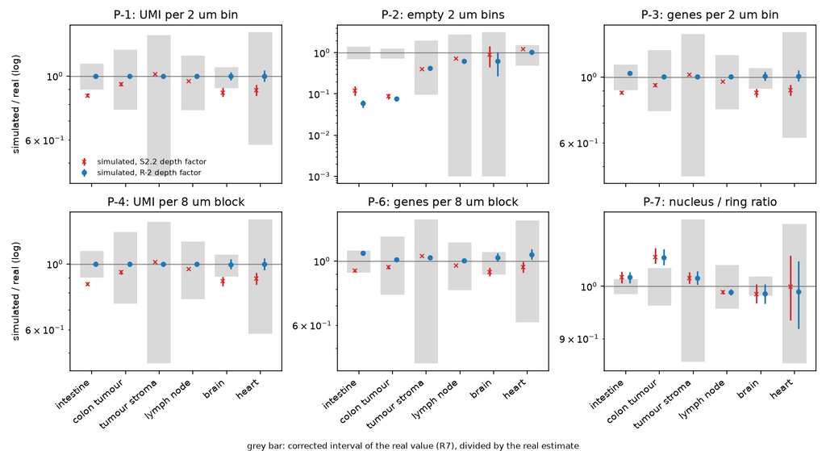

Simulato / vero per misura e tessuto (scala logaritmica). Croci rosse: fattore di profondità di S2.2 (pannello main); cerchi blu: fattore ritarato con la regola R-2 (pannello main_r2), con l’intervallo del simulato. Barra grigia: intervallo corretto del vero diviso per la stima vera (dove il limite inferiore è 0 la barra è tagliata a 10⁻³).

**Cosa guardare**: dopo R-2 i cerchi blu stanno sull’1 per trascritti e geni in tutti i tessuti; restano fuori i quadratini vuoti di intestino e tumore (P-2, un decimo e meno) e il rapporto nucleo/corona del tumore (P-7).

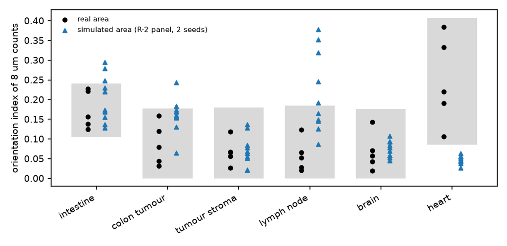

Indice di orientamento dei conteggi a 8 µm per area: aree vere (cerchi neri) e simulate (triangoli blu, pannello main_r2, due semi). Barra grigia: intervallo corretto del vero.

**Cosa guardare**: nel cuore le aree vere sono orientate (le fibre), le simulate no (controllo negativo, CP-2). Nel linfonodo e nell’intestino il simulato è più orientato del vero (bordi delle regioni e strisce; BL-236).

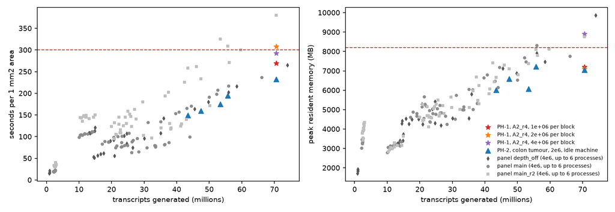

Tempo e picco di memoria per area di 1 mm² contro i trascritti generati: pannelli (4 × 10⁶ trascritti per blocco, fino a 6 processi sul server condiviso), PH-1 (area A2_r4 con blocchi da 4, 2 e 1 milione) e PH-2 (aree del tumore con i predefiniti finali, macchina libera). Linee rosse: bilancio del design (300 s, 8 GB).

**Cosa guardare**: la memoria cresce con i trascritti generati; con blocchi più piccoli scende da 8.9 a circa 7 GB e poi non più; a macchina libera tutte le aree del tumore stanno nel bilancio.

# Controprova

CP-1: P-1 con il fattore di profondità spento (`results/S2.5/S2.5_verdicts_depth_off.csv`).

| tessuto | intervallo del vero | simulato senza fattore di profondità | esito |
| --- | --- | --- | --- |
| intestino | [26.21, 32.34] | 28.8 [28.6, 29.01] | confermata |
| tumore del colon | [36.61, 59.26] | 50.29 [49.08, 51.54] | confermata |
| stroma | [8.643, 26.72] | 12.4 [12.33, 12.5] | confermata |
| linfonodo | [8.76, 13.56] | 14.08 [14.04, 14.13] | smentita |
| cervello | [40.43, 47.77] | 31.23 [30.28, 32.25] | smentita |
| cuore | [2.056, 5.048] | 1.212 [1.177, 1.251] | smentita |

CP-2 è il giudizio P-9 nel cuore (tabella dei giudizi e figura 2).

# Analisi post hoc

- **PH-1, memoria contro blocchi** (`tools/S2.5_PH1_memory.R`, `/mnt/micron/geo_spatialtrans/S2.5/PH1/`): area A2_r4, 70.6 milioni di trascritti generati, un processo, carico medio circa 10: 4 × 10⁶ trascritti per blocco 8.9 GB e 293 s; 2 × 10⁶ 7.1 GB e 308 s; 1 × 10⁶ 7.2 GB e 270 s. Sotto circa 7 GB non si scende: pesano le tabelle dell’area intera (trascritti per terna, origine, matrici), quindi un’area di cattura intera va fatta a tessere (BL-214).
- **PH-2, tempo del tumore a macchina libera** (`tools/S2.5_PH2_timing.R`, carico medio 0.1-1.4): 5 aree del tumore con i predefiniti finali (fattore di R-2, 2 × 10⁶): 149.3-232.4 s (media 182 ± 29 s, 2 errori standard), picco 6.0-7.2 GB. Chiude l’esito indeterminato di P-8 in main_r2 (dovuto al carico).

# Revisione avversariale

Tre revisori indipendenti con codice proprio, in sola lettura (`/mnt/micron/geo_spatialtrans/S2.5/review/{numeri,codice,esiti}/`).

- **Numeri** (misure vere di 6 aree dalle matrici raw, misure simulate di 6 esecuzioni dalle matrici salvate, orientamento del cuore): 36/36, 36/36, 10/10 entro la tolleranza (scarto massimo relativo 2.1e-13); md5 dei 78 file letti invariati. Rilievi: (i) l’indice di orientamento non vale 0 per un campo senza correlazione (rumore puro circa 0.5), quindi «0 = isotropo» (E-4) vale solo per campi ben correlati; nel cuore vero l’orientamento è del tessuto (resta senza effetti di riga e colonna, con la sola maschera interna, con i trascritti dimezzati; angoli diagonali; area A6_r5 guidata dal bordo); nel linfonodo simulato A4_p1 contano rumore e strisce (indice 0.263 → 0.143 senza effetti di riga e colonna), contro la frase di E-4; (ii) gli angoli del lato vero sono in coordinate della griglia di Space Ranger, con un asse invertito rispetto all’immagine (nessun esito usa gli angoli); (iii) nell’intestino alcuni quadratini delle regioni mancano dalla matrice raw (nessuna lettura) e contano come vuoti: 303 su 157 387 in A1_r2, un quinto dei vuoti dell’area; coerente con le somme a 8 µm di Space Ranger.
- **Codice** (lettura della funzione contro il documento di progetto e questo file, test propri su un livello sintetico, 6 esecuzioni reali): semi del pannello 105/105 ricostruiti in Python puro; verità a 8 µm con indice del blocco proprio esatta; allineamento delle cellule, profondità, regola dei blocchi esatti sul livello sintetico e su 6 esecuzioni reali. Difetti: generatore senza seme (C-2), strati senza nome (C-3). Controlli deboli: griglia data e verità a 8 µm (C-4). Rilievi minori: per l’orientamento il punto 6 di DEC-060 indica il fattore delle «altre quantità» (sensibilità, nessun esito cambia); con `frame_open` il riquadro è quello delle regioni, non la finestra (A1_r1: tessuto da 5.48 µm, bordo sinistro trattato come aperto; BL-237); Box-Muller (BL-238). Deviazioni dichiarate dal revisore: semi di main_r2 controllati su 9 file (in corso), s24_identity non ancora girata.
- **Esiti** (intervalli e esiti di main, main_r2, depth_off, P-8, R-2, controprove, sensibilità): quantità deterministiche entro 1.3e-13; estremi del bootstrap compatibili con 20 000 bootstrap indipendenti (probabilità di coda minima 0.0175 per il vero, 0.0096 per il simulato, soglia 0.001); esiti 142/144 uguali all’esito modale. I due diversi sono nel pannello main, cervello, P-1 e P-4: lo step dice indeterminata, l’esito modale è smentita (probabilità 0.87 e 0.78): il simulato è a ridosso dell’estremo del vero e decide il seme del bootstrap (B = 2000); dopo R-2 confermate con probabilità 1. R-2 identica (1e-15) e usata davvero in main_r2; CP-1 e CP-2 reggono con probabilità 1.

# Cosa è girato

- Commit dei cancelli `3badae6`, ok di Luca `e155d62`, calcolo, revisione e correzioni `5eed7c8`; ramo `step2-visium-grid`; R 4.6, Python del progetto (`.venv`).
- Funzione: `R/05b5_simulate_visium_hd.R` (`simulate_visium_hd`, `visium_hd_archetype`, `visium_hd_chunk_size`, `visium_hd_depth_factor`); batteria `R/testing/test_S2.5.R` (40/40), mutanti `tools/S2.5_mutants.py` (16/16).
- Lato vero: `tools/S2.5_real.py`, `tools/S2_5_common.py`; statistiche `tools/S2.5_stats.py`; pannello `tools/S2.5_panel.R` (semi estratti con Mersenne-Twister dal seme 20261109), esiti e regola R-2 `tools/S2.5_analysis.py`, verità a 8 µm `tools/S2.5_truth8_check.R`; riproduzione e identità `tools/S2.5_repro.sh`, `tools/S2.5_identity.sh`; post hoc `tools/S2.5_PH1_memory.R`, `tools/S2.5_PH2_timing.R`; uscite in `/mnt/micron/geo_spatialtrans/S2.5/`.
- Processi: al più 6; server condiviso. Pannello main (60 esecuzioni) circa 18 minuti; depth_off (30) circa 10 minuti; main_r2 (60) circa 26 minuti, insieme ai mutanti e ai revisori.
- md5 dei 230 file letti identici prima e dopo (`results/S2.5/S2.5_md5_before.txt`, `_after.txt`, `_diff.txt` vuoto).
- A metà della chiusura il server non era raggiungibile dalla VPN; il lavoro è proseguito con un secondo accesso alla stessa macchina.

## Esplorazioni prima della pre-registrazione

- **E-0, dati veri: geni e blocchi di 8 µm** (`tools/S2.5_real.py`). Le matrici raw di Space Ranger hanno anche i geni fuori dal pannello di sonde (intestino: 32 285 contro 19 059 della matrice filtrata usata da R4): le misure usano le sole feature della matrice filtrata. Ogni blocco di 8 µm di Space Ranger è la somma dei suoi 16 quadratini di 2 µm, con indici (riga // 4, colonna // 4): 678 597 su 678 597 nella sezione dell’intestino, tutti i blocchi completi delle 30 aree. Con la definizione di Space Ranger le misure per area riproducono `R4_roi.csv` (6 misure × 30 aree, scarto massimo 1.1e-13).
- **E-1, due definizioni del tessuto** (`/mnt/micron/geo_spatialtrans/S2.5/explore/real_side/S2.5_real_refs.csv`). I valori veri adottati dopo R7 contano come tessuto i quadratini marcati da Space Ranger nel riquadro dell’area (definizione «sr», R4). Il simulato conosce solo le regioni dello Step 1; S2.3 e S2.4 confrontavano sugli stessi quadratini dei due lati: centro (allineato con lo scarto della sezione) nelle regioni e a ≥ 25 µm dal bordo dell’area (definizione «reg»). Le due definizioni danno valori veri diversi: intestino UMI per quadratino di 2 µm 29.27 (reg) contro 27.14 (sr), frazione di vuoti 0.0067 contro 0.0159; tumore del colon vuoti 0.0056 contro 0.0104; linfonodo 0.0087 contro 0.0117. Intervalli ricostruiti con le regole di DEC-060: la ricostruzione con la definizione sr ridà l’intervallo adottato (intestino, UMI a 2 µm: 24.67-29.64 contro 24.64-29.64 della tabella di R7; differenza dal seme del bootstrap).
- **E-2, catena completa con l’orchestratore** (variante `explore`: un’area per tessuto, seme 20261110). 21-163 s e 2.9-6.7 GB per area con i blocchi della regola R-1; conservazione, identità a 8 µm e verità a 8 µm esatte in 6 su 6. Simulato / vero della stessa area, UMI a 2 µm: 0.94 (intestino), 0.85 (tumore), 1.00 (stroma), 0.90 (linfonodo), 0.85 (cervello), 0.64 (cuore; l’area A6_r1 ha più UMI della media del cuore).
- **E-3, potere del confronto** (pannello di S2.4, 60 esecuzioni della stessa catena, UMI e vuoti a 2 µm, definizione reg). Il simulato varia poco fra le aree (la profondità è per tessuto), quindi l’intervallo del simulato è stretto e il confronto con l’intervallo del vero ha potere; il confronto appaiato area per area ne ha meno (porta con sé la variabilità delle aree vere). Con la regola di DEC-061: UMI smentito nell’intestino (25.0 contro 26.2-32.3) e nel cervello (38.6 contro 40.4-47.8), confermato negli altri quattro; vuoti smentiti nell’intestino e nel tumore. BL-219: 522 geni del pannello hanno profilo nullo nello stroma (i 111 assenti dall’atlante di S2.2 più quelli presenti ma mai espressi nei sottotipi dello stroma); portano lo 0.99 % degli UMI veri nelle 5 aree dello stroma, intervallo corretto 0.45-1.67 % (`S2.5_BL219_share.csv`).
- **E-4, orientamento del tessuto** (`tools/S2_5_common.py` `aniso`: autocorrelazione del logaritmo degli UMI dei blocchi di 8 µm in tessuto, tensore dei momenti a 8-32 µm, indice 0 = isotropo). Veri: cuore 0.25 (0.11-0.38; angolo 46-56° in 4 aree su 5), intestino 0.17, tumore 0.09, stroma 0.07, linfonodo 0.06, cervello 0.07. Simulato (una area): cuore 0.04; intestino 0.23, tumore 0.23, linfonodo 0.18. Togliere gli effetti di riga e colonna (strisce) non abbassa il simulato: l’orientamento del simulato viene dal contrasto ai bordi delle regioni e dei lumi, quello del cuore vero dall’interno del tessuto (fibre). Il cuore è quindi un controllo negativo misurabile (CP-2).
- **E-5, memoria** (S2.4 PH-1, cervello A5_r1, 883 cellule, 38.75 milioni di trascritti generati): un blocco unico → 19.8 GB; blocchi di 200 cellule (circa 8.8 milioni di trascritti per blocco) → 5.8 GB. Il picco cresce con i trascritti per blocco; con 4 milioni per blocco E-2 misura 2.9-6.7 GB (massimo nel tumore, A2_r1, 577 cellule per blocco). BL-212 in E-2: quadratini in tessuto senza territorio 141 su 186 605 nel cervello A5_r1 (0.08 %), 1 nel cuore, 0 altrove.

## Attese pre-registrate

Commit dei cancelli: `3badae6` («S2.5: perimetro, esplorazioni, funzione, cancelli»). Ok di Luca sulle previsioni P-1…P-9, sulle soglie (intervalli corretti di R7; «meno di un blocco vuoto per area» dove il vero è sempre zero), sulla regola R-2 e sulle controprove: 2026-11-09, «Ok, come proposte (Recommended)». Commit `e155d62` («S2.5: ok di Luca sulle previsioni (2026-11-09)»).

Semi: pannello, seme dell’utente per (area, k) estratto con Mersenne-Twister dal seme 20261109 (k = 0, 1); l’orchestratore ne estrae i semi dei quattro passi; esplorazione seme 20261110; bootstrap B = 2000, semi da 20261121. Unità indipendente: l’area (5 per tessuto), con le correzioni di R7 per le poche aree e le zone comuni. Processi: al più 6, dal file `WORKERS` (server condiviso, limite termico). Uscite in `/mnt/micron/geo_spatialtrans/S2.5/` (un file per esecuzione, rilanciabile); tabelle in `results/S2.5/`.

### Le funzioni

File `R/05b5_simulate_visium_hd.R`; batteria `R/testing/test_S2.5.R`.

1. **`simulate_visium_hd(cell_layer, seed, archetype, layers, frame_open, profiles, depth_factor, chunk_size, chunk_transcripts, component_seeds, hd, workers)`**: `build_hd_grid()` (o la griglia data, controllata contro il livello), `simulate_stripes()`, `simulate_cell_profiles()` con il fattore di profondità per M, `place_and_move_transcripts()` con la seconda coda, `capture_and_bin()`. Strati spegnibili: strisce, fondo, campo, seconda coda. Uscita come la sezione 1 del documento di progetto: `counts_2um`, `counts_8um`, `bins`, `bins_8um`, `truth$overlap` e `overlap_8um`, `origin` e `origin_8um`, `background` e `background_8um`, `arrived_2um` (trascritti arrivati per quadratino prima della cattura), `cell_counts` (generati, M volte la scala di R4), `cells` (tipo, sottotipo, generati, persi, scartati, catturati, atteso catturato), `genes`, `layers` (strisce, fondo, seconda coda, spostamento, campo, profondità), `metadata` (scala, archetipo, semi, strati, blocchi, M, tempi).
2. **`visium_hd_chunk_size(n_transcripts, chunk_transcripts = 4e6, max_cells = 2000)`**: cellule per blocco = ⌊chunk_transcripts / media dei trascritti generati per cellula⌋, fra 1 e 2 000 (regola R-1).
3. **`visium_hd_archetype(cell_layer)`**: archetipo dal preset del livello.
4. Semi: quattro estrazioni Mersenne-Twister dal seme dell’utente (strisce, profili, posizione, cattura); stato del generatore dell’utente ripristinato; risultato indipendente da `workers`.

### Il pannello

Le 30 aree dello Step 1 (livelli U6 di S1.6), griglie di S2.3 (controllate), `frame_open = TRUE`, tutti gli strati accesi, 2 semi (variante `main`). Varianti: `depth_off` (fattore di profondità 1, semi di main k = 0; CP-1), `s24_identity` (A2_r1, A6_r1 con i semi dei passi e i blocchi di 2 000 cellule del pannello di S2.4; G-4), `main_r2` (dopo la regola R-2, stessi semi di main).

### Definizioni delle misure

Stesse funzioni sui due lati (`tools/S2_5_common.py`; lato vero `tools/S2.5_real.py`, lato simulato `tools/S2.5_stats.py`).

- Quadratini: definizione **reg** (vedi E-1). Blocchi di 8 µm: almeno 8 dei 16 quadratini in reg. Misure: UMI medio, frazione di vuoti, geni rilevati medi a 2 e 8 µm; rapporto nucleo/corona (statistica di R4 PH-1, densità media nel nucleo / nella corona di 8 µm, diviso la stessa con la maschera spostata di 20 µm; funzione del pannello di S2.3, lato vero di S2.3); orientamento dei blocchi di 8 µm (E-4).
- Valore del tessuto: media delle 5 aree (simulato: prima la media dei 2 semi nell’area).
- Intervallo del vero (= intervallo di rilevanza, DEC-061): bootstrap percentile della media sulle 5 aree, semi-ampiezze per il fattore del tessuto `kappa_boot_bin` di R7, per il fattore dell’asimmetria se il CV fra aree supera 0.45, limite inferiore portato a 0 (DEC-060 punti 1, 2, 6, 7).
- Intervallo del simulato: stessa costruzione con il fattore del lato simulato (riga `sim_5`, 1.632; DEC-060 punto 3), senza fattore dell’asimmetria.
- Esito: intervallo del simulato tutto dentro l’intervallo del vero, confermata; tutto fuori, smentita; a cavallo, indeterminata.
- Intervalli del vero di ampiezza nulla (vuoti a 8 µm in intestino, tumore e cervello: 0 in tutte le aree): l’intervallo di rilevanza diventa [0, 1/n₈], con n₈ i blocchi in tessuto medi per area (meno di un blocco vuoto per area).
- Sensibilità (senza esito): le stesse misure con la definizione sr contro gli intervalli della tabella adottata di R7; il rapporto nucleo/corona anche contro la banda di ±10 % approvata in S2.3.

### Regole di decisione dei dati (scritte prima del calcolo)

**R-1, blocchi di cellule** (BL-227). `chunk_transcripts` = 4 × 10⁶ trascritti generati per blocco, dalla memoria per fase di S2.4 (E-5); la funzione di posizione e spostamento lavora a blocchi di `visium_hd_chunk_size()` cellule. I blocchi cambiano le estrazioni, non il modello. Si giudica con P-8.

**R-2, fattore di profondità sulla catena completa** (BL-205, D2-9). S2.2 ha tarato il fattore senza le perdite dello spostamento e il fondo dei valori veri di R5, e ha rinviato la verifica a questo step. Dopo il pannello `main`, per ogni tessuto: f’ = f · (U_vero − b) / (U_sim − b), con U l’UMI medio per quadratino di 2 µm in tessuto (definizione reg; U_sim del pannello main) e b il fondo della cattura del tessuto (UMI per quadratino; la media di c sul tessuto è 1). Un passo solo, in tutti e sei i tessuti; si rifà il pannello (`main_r2`) e si rigiudicano P-1…P-9. Le previsioni del pannello main dicono come si comporta il simulatore di oggi; quelle di `main_r2` sono il verdetto sul preset che resta. Se dopo R-2 l’UMI non è confermato in un tessuto, nessuna seconda iterazione: dubbio.

### Cancelli (al massimo 5)

Soglia per i confronti multipli: |z| < Φ⁻¹(1 − 0.0005/m), m = numero di confronti.

| id | controllo | tolleranza | comando |
| --- | --- | --- | --- |
| G-1 | **batteria di test** (35 asserzioni): (a) equivalenza con la catena a mano (due tessuti, `frame_open`, griglia costruita); (b) identità delle uscite: `counts_8um`, `origin_8um`, `overlap_8um`, `backgr… | identità esatte; mutanti 100 % | `R_LIBS_SITE=/nonexistent R_LIBS_USER=/nonexistent Rscript --vanilla R/testing/test_S2.5.R`; `.venv/bin/python tools/S2.5_mutants.py` |
| G-2 | **invarianti del pannello** (main, depth_off, main_r2): conservazione per cellula, gene, quadratino; somma a 8 µm; verità a 8 µm; nessun NA; catturati entro la soglia di Bonferroni dall’atteso Σ arriv… | identità; z sotto la soglia | `Rscript --vanilla tools/S2.5_panel.R check <dir>` |
| G-3 | **riproducibilità**: lato vero, pannello main k = 0, misure e tabelle degli esiti rifatti in un’altra cartella con un numero di processi diverso | md5 identici (JSON senza i tempi) | `tools/S2.5_repro.sh` |
| G-4 | **integrità e continuità**: (a) md5 di ogni file letto prima e dopo (matrici e posizioni delle 5 sezioni, tabelle di R2, R4, R7, livelli di S1.6, griglie e strati esportati di S2.3, lato vero di S2.3,… | identità; (d) entro 1e-9 | `tools/S2.5_md5.sh before / after`; batterie; `tools/S2.5_identity.sh` |
| G-5 | **revisione avversariale**: sotto-agenti con codice proprio ricalcolano (a) le misure vere (reg) di un’area per tessuto dalle matrici raw; (b) le misure simulate di 6 esecuzioni dalle matrici salvate;… | quantità deterministiche entro 1e-9 relativo; ogni discrepanza è un dubbio | sotto-agenti, report |

### Previsioni

Intervallo di rilevanza: l’intervallo corretto del valore vero del tessuto (DEC-061), definizione reg (decisione chiesta a Luca, sotto). Esiti per tessuto, sul pannello main e dopo R-2.

[output not shown]

P-8: intervallo di rilevanza 0-300 s e 0-8 GB (bilancio del documento di progetto, sezione 12), media delle 5 aree ± 2 errori standard come in S2.4.

### Controprova

- **CP-1, il confronto vede un simulatore sbagliato?** Pannello con il fattore di profondità tolto (1, un seme): UMI per quadratino di 2 µm smentita nel linfonodo (f = 0.79: circa 14.0 contro 8.8-13.6), nel cervello (1.25: circa 31 contro 40.4-47.8) e nel cuore (2.62: circa 1.2 contro 2.1-5.0). Se uno dei tre non risulta smentito, lì il confronto non ha potere. Intestino, tumore (f vicino a 1) e stroma (intervallo del vero largo) non dicono nulla.
- **CP-2, il cuore come controllo negativo** (documento di progetto, sezione 15). Il simulatore ha cellule isotrope; i conteggi veri del cuore hanno un orientamento che viene dall’interno del tessuto (E-4). P-9 deve risultare smentita per difetto nel cuore. Se non lo è, la misura non vede un limite noto del simulatore.

### Misure (senza intervallo)

- Blocchi scelti e fattore M per area; tempi per passo.
- BL-212: quadratini in tessuto senza territorio, per area (attesa: meno di un millesimo).
- Sensibilità: esiti con la definizione sr e la tabella adottata di R7; rapporto nucleo/corona contro ±10 %.
- Fattori di profondità prima e dopo R-2.

## Decisioni chieste a Luca prima del calcolo

1. **Definizione del tessuto per il confronto** (E-1). Luca, 2026-11-09: «Stessi quadratini sui due lati (Recommended)»: definizione reg sui due lati, valori veri ricalcolati su quei quadratini con le regole di correzione di R7; la tabella adottata di R7 (definizione sr) si riporta come sensibilità, senza esito. Da registrare come decisione.
2. **Geni dello stroma senza profilo** (BL-219, E-3). Luca, 2026-11-09: «Lasciarli come limite dichiarato (Recommended)»: nessun cambio ai profili di S2.2; limite dichiarato nel documento di progetto (sezione 17). Da registrare come decisione.

## Correzioni dopo il calcolo

- **C-1, strumento dei mutanti**: il frammento del mutante «`frame_open` non passato» compariva due volte (anche nei metadati); reso univoco e rieseguito.
- **C-2, generatore dell’utente** (revisore del codice): con l’utente senza `.Random.seed`, dopo la chiamata ne restava uno seminato dall’orologio (una funzione compilata di imager chiamata dalla posizione dei trascritti lo crea prima che lo stato sia registrato). L’orchestratore registra e ripristina lo stato in testa; nessun effetto sui risultati (ogni passo usa i suoi semi). Test e6, mutante nuovo. Resta, comune a tutte le funzioni dei passi: con `normal.kind = "Box-Muller"` la memoria interna di Box-Muller non si ripristina (BL-238).
- **C-3, strati senza nome** (revisore del codice): `layers = list(FALSE)` era accettato e ignorato; ora errore (test f5b, mutante nuovo).
- **C-4, controlli deboli** (revisore del codice): la griglia data si controlla anche con il seme dello Step 1 e l’area del territorio di ogni cellula (test f6b, mutante nuovo; nel pannello le 30 griglie erano coerenti, verificato dal revisore); la verità a 8 µm si controlla per coppia (blocco, cellula) su tutte le 150 esecuzioni (`tools/S2.5_truth8_check.R`).
- **C-5, mutante equivalente**: dopo C-2 il mutante che toglie il solo ripristino interno del generatore non cambia il comportamento; sostituito con quello che toglie entrambi i ripristini (rilevato).
- **C-6, blocchi predefiniti**: dopo PH-1 il valore predefinito di `chunk_transcripts` passa da 4 × 10⁶ a 2 × 10⁶ (DEC-068); lo script del pannello fissa 4 × 10⁶ e il fattore di S2.2 per le varianti girate così (G-3 identico).
- **C-7, profondità del preset**: i fattori di R-2 entrano nell’orchestratore come predefinito per i profili dei preset (`visium_hd_depth_factor()`, test d5 e d6, mutante nuovo; DEC-067).

## Deviazioni dichiarate

- Correzioni C-1…C-7 (sopra); test e mutanti aggiunti dopo la revisione.
- **Errore di pre-registrazione**: per l’orientamento (P-9) la regola di R7 chiede il fattore delle altre quantità (`kappa_boot_box`) e non quello dei quadratini; P-9 è giudicata come scritta, con la correzione come sensibilità (nessun esito cambia).
- E-4: la frase «togliere gli effetti di riga e colonna non abbassa il simulato» vale per l’area esplorata, non per il linfonodo A4_p1 (revisore dei numeri).
- P-8: il tempo è quello della sola chiamata dell’orchestratore (`elapsed_sim_s`, senza la scrittura dei file); la memoria è il picco del processo.
- Il pannello main_r2 e la revisione sono girati insieme (server carico): tempi di main_r2 non confrontabili con main; rimisurati in PH-2.
- La connessione al server è caduta (VPN) durante la chiusura; il lavoro è proseguito con il secondo accesso allo stesso server (`lesexp-ts`).
- Un file di registro di un revisore (`sim_extract.log`) era finito nella root del repo; spostato nella cartella del revisore.

# Appendice: da dove vengono i numeri del riassunto

| frase del riassunto | fonte | valore letto |
| --- | --- | --- |
| dopo la ritaratura trascritti e geni tornano sul vero in tutti e sei i tessuti, a 2 e a 8 µm | `results/S2.5/S2.5_verdict_counts_main_r2.csv` (P-1, P-3, P-4, P-6) | 6 confermate su 6 per ciascuna |
| l’intestino aveva 14 trascritti su 100 in meno, il cervello 12 | `S2.5_verdicts_main.csv` (P-1, colonna ratio) | 0.856 (intestino), 0.877 (cervello) |
| il fattore nuovo cambia di 1 % in meno nello stroma, 17 % in più nell’intestino | `S2.5_R2_depth.csv` | 1.584 → 1.561; 0.867 → 1.013 |
| geni e blocchi da 8 µm, non tarati, tornano | `S2.5_verdicts_main_r2.csv` (P-3, P-4, P-6) | geni a 8 µm simulato / vero 1.005-1.064 |
| senza fattore di profondità fuori dal vero in linfonodo, cervello, cuore | `S2.5_verdicts_depth_off.csv` (P-1) | 14.08 contro 8.76-13.56; 31.23 contro 40.43-47.77; 1.21 contro 2.06-5.05 |
| vuoti da un diciassettesimo a un tredicesimo in intestino e tumore | `S2.5_verdicts_main_r2.csv` (P-2) | simulato / vero 0.059, 0.076 |
| contrasto nucleo/citoplasma del tumore 0,90 contro 0,82-0,88; con ±10 % sarebbe giusto | `S2.5_verdicts_main_r2.csv` (P-7 A2); `S2.5_sensitivity_main_r2.csv` (star_ratio) | 0.901 [0.888, 0.917] contro [0.818, 0.883]; banda ±10 % confermata 6/6 |
| cuore: vero 0,25, simulato 0,05 | `S2.5_verdicts_main_r2.csv` (P-9 A6, real_est e sim_est) | 0.247 e 0.048 |
| il tumore a macchina libera da 2 minuti e mezzo a 4 minuti, picco da 6 a 7,2 GB | `results/S2.5/PH2/*.json` | 149.3-232.4 s; 6 009-7 225 MB |
| con i blocchi di prima un’area del tumore arrivava a 8,9 GB; sotto 7 GB non si scende | `results/S2.5/PH1/*.json` | 8 909 MB (4 × 10⁶), 7 108 MB (2 × 10⁶), 7 211 MB (1 × 10⁶) |
| con i quadratini di Space Ranger l’intestino risulterebbe sopra il vero nei geni | `S2.5_sensitivity_main_r2.csv` (A1, mean_genes) | 2 µm: 27.58-28.41 contro 23.02-27.39; 8 µm: 372.1-382.5 contro 299.4-347.4 |
| tre revisori, due difetti corretti; due esiti del cervello decisi dal caso del ricampionamento | `/mnt/micron/geo_spatialtrans/S2.5/review/*/`; `review/esiti/summary_nrep20000.txt` | P-1 e P-4 del cervello (pannello main): probabilità di smentita 0.872 e 0.777 |
| tempi del pannello: circa 18, 10 e 26 minuti | `/mnt/micron/geo_spatialtrans/S2.5/run_main.log`, `run_r2.log` | main 16:50:32-17:08:21; depth_off 17:08:21-17:17:50; main_r2 17:20:38-17:46:39 |